# ISLR Problems 4

Alex Bayers

10/19/2018

## Chapter 4 Problems

### Problem 10

##### A.

```r
library(ISLR)
attach(Weekly)
summary(Weekly)
```

```
##       Year           Lag1               Lag2               Lag3
##  Min.   :1990   Min.   :-18.1950   Min.   :-18.1950   Min.   :-18.1950
##  1st Qu.:1995   1st Qu.: -1.1540   1st Qu.: -1.1540   1st Qu.: -1.1580
##  Median :2000   Median :  0.2410   Median :  0.2410   Median :  0.2410
##  Mean   :2000   Mean   :  0.1506   Mean   :  0.1511   Mean   :  0.1472
##  3rd Qu.:2005   3rd Qu.:  1.4050   3rd Qu.:  1.4090   3rd Qu.:  1.4090
##  Max.   :2010   Max.   : 12.0260   Max.   : 12.0260   Max.   : 12.0260
##       Lag4               Lag5              Volume
##  Min.   :-18.1950   Min.   :-18.1950   Min.   :0.08747
##  1st Qu.: -1.1580   1st Qu.: -1.1660   1st Qu.:0.33202
##  Median :  0.2380   Median :  0.2340   Median :1.00268
##  Mean   :  0.1458   Mean   :  0.1399   Mean   :1.57462
##  3rd Qu.:  1.4090   3rd Qu.:  1.4050   3rd Qu.:2.05373
##  Max.   : 12.0260   Max.   : 12.0260   Max.   :9.32821
##      Today          Direction
##  Min.   :-18.1950   Down:484
##  1st Qu.: -1.1540   Up  :605
##  Median :  0.2410
##  Mean   :  0.1499
##  3rd Qu.:  1.4050
##  Max.   : 12.0260
```

```r
cor(Weekly[,-9])
```

```
##               Year         Lag1        Lag2        Lag3         Lag4
## Year    1.00000000 -0.032289274 -0.03339001 -0.03000649 -0.031127923
## Lag1   -0.03228927  1.000000000 -0.07485305  0.05863568 -0.071273876
## Lag2   -0.03339001 -0.074853051  1.00000000 -0.07572091  0.058381535
## Lag3   -0.03000649  0.058635682 -0.07572091  1.00000000 -0.075395865
## Lag4   -0.03112792 -0.071273876  0.05838153 -0.07539587  1.000000000
## Lag5   -0.03051910 -0.008183096 -0.07249948  0.06065717 -0.075675027
## Volume  0.84194162 -0.064951313 -0.08551314 -0.06928771 -0.061074617
## Today  -0.03245989 -0.075031842  0.05916672 -0.07124364 -0.007825873
##                Lag5      Volume        Today
## Year   -0.030519101  0.84194162 -0.032459894
## Lag1   -0.008183096 -0.06495131 -0.075031842
## Lag2   -0.072499482 -0.08551314  0.059166717
## Lag3    0.060657175 -0.06928771 -0.071243639
## Lag4   -0.075675027 -0.06107462 -0.007825873
## Lag5    1.000000000 -0.05851741  0.011012698
## Volume -0.058517414  1.00000000 -0.033077783
## Today   0.011012698 -0.03307778  1.000000000
```

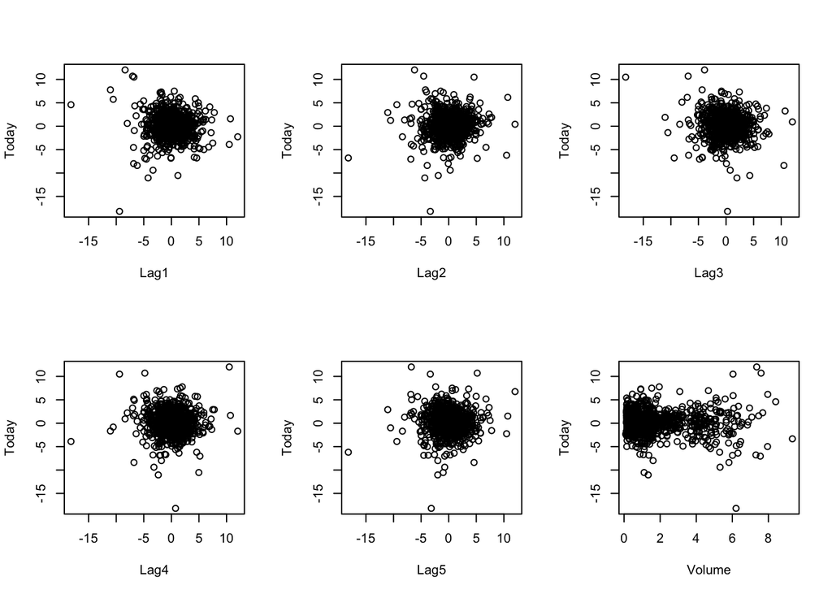

```r
par(mfrow=c(2, 3))
plot(Today ~ Lag1)
plot(Today ~ Lag2)
plot(Today ~ Lag3)
plot(Today ~ Lag4)
plot(Today ~ Lag5)
plot(Today ~ Volume )
```

Nothing stands out terribly obviously, though large moves both up and down seem correlated with large volume periods.

##### B.

```r
glm.fit=glm(Direction  ~ Lag1+Lag2+Lag3+Lag4+Lag5+Volume , data=Weekly, family=binomial)
summary(glm.fit)
```

```
##
## Call:
## glm(formula = Direction ~ Lag1 + Lag2 + Lag3 + Lag4 + Lag5 +
##     Volume, family = binomial, data = Weekly)
##
## Deviance Residuals:
##     Min       1Q   Median       3Q      Max
## -1.6949  -1.2565   0.9913   1.0849   1.4579
##
## Coefficients:
##             Estimate Std. Error z value Pr(>|z|)
## (Intercept)  0.26686    0.08593   3.106   0.0019 **
## Lag1        -0.04127    0.02641  -1.563   0.1181
## Lag2         0.05844    0.02686   2.175   0.0296 *
## Lag3        -0.01606    0.02666  -0.602   0.5469
## Lag4        -0.02779    0.02646  -1.050   0.2937
## Lag5        -0.01447    0.02638  -0.549   0.5833
## Volume      -0.02274    0.03690  -0.616   0.5377
## ---
## Signif. codes:  0 '***' 0.001 '**' 0.01 '*' 0.05 '.' 0.1 ' ' 1
##
## (Dispersion parameter for binomial family taken to be 1)
##
##     Null deviance: 1496.2  on 1088  degrees of freedom
## Residual deviance: 1486.4  on 1082  degrees of freedom
## AIC: 1500.4
##
## Number of Fisher Scoring iterations: 4
```

Lag 2 seems statistically significant. We refit the model with just the first two predictors to obtain the following.

```r
glm.fit=glm(Direction  ~ Lag1+Lag2, data=Weekly, family=binomial)
summary(glm.fit)
```

```
##
## Call:
## glm(formula = Direction ~ Lag1 + Lag2, family = binomial, data = Weekly)
##
## Deviance Residuals:
##    Min      1Q  Median      3Q     Max
## -1.623  -1.261   1.001   1.083   1.506
##
## Coefficients:
##             Estimate Std. Error z value Pr(>|z|)
## (Intercept)  0.22122    0.06147   3.599 0.000319 ***
## Lag1        -0.03872    0.02622  -1.477 0.139672
## Lag2         0.06025    0.02655   2.270 0.023232 *
## ---
## Signif. codes:  0 '***' 0.001 '**' 0.01 '*' 0.05 '.' 0.1 ' ' 1
##
## (Dispersion parameter for binomial family taken to be 1)
##
##     Null deviance: 1496.2  on 1088  degrees of freedom
## Residual deviance: 1488.2  on 1086  degrees of freedom
## AIC: 1494.2
##
## Number of Fisher Scoring iterations: 4
```

This refit confirms our results. Further, we remove the first lag know and refit.

```r
glm.fit=glm(Direction  ~ Lag2, data=Weekly, family=binomial)
summary(glm.fit)
```

```
##
## Call:
## glm(formula = Direction ~ Lag2, family = binomial, data = Weekly)
##
## Deviance Residuals:
##    Min      1Q  Median      3Q     Max
## -1.564  -1.267   1.008   1.086   1.386
##
## Coefficients:
##             Estimate Std. Error z value Pr(>|z|)
## (Intercept)  0.21473    0.06123   3.507 0.000453 ***
## Lag2         0.06279    0.02636   2.382 0.017230 *
## ---
## Signif. codes:  0 '***' 0.001 '**' 0.01 '*' 0.05 '.' 0.1 ' ' 1
##
## (Dispersion parameter for binomial family taken to be 1)
##
##     Null deviance: 1496.2  on 1088  degrees of freedom
## Residual deviance: 1490.4  on 1087  degrees of freedom
## AIC: 1494.4
##
## Number of Fisher Scoring iterations: 4
```

This model fit further confirms the results of lag 2.

##### C.

```r
glm.pred=rep("Down",1089)
glm.probs=predict(glm.fit,type="response")
glm.pred[glm.probs >.5]="Up"
table(glm.pred,Direction)
```

```
##         Direction
## glm.pred Down  Up
##     Down   33  26
##     Up    451 579
```

```r
mean(glm.pred==Direction )
```

```
## [1] 0.5619835
```

```r
print(605/(605+484))
```

```
## [1] 0.5555556
```

##### D.

```r
test = (Year > 2008)
Weekly.train = Weekly[!test,]
Weekly.test = Weekly[test,]
glm.fit.train=glm(Direction  ~ Lag2, data=Weekly.train, family=binomial)
summary(glm.fit.train)
```

```
##
## Call:
## glm(formula = Direction ~ Lag2, family = binomial, data = Weekly.train)
##
## Deviance Residuals:
##    Min      1Q  Median      3Q     Max
## -1.536  -1.264   1.021   1.091   1.368
##
## Coefficients:
##             Estimate Std. Error z value Pr(>|z|)
## (Intercept)  0.20326    0.06428   3.162  0.00157 **
## Lag2         0.05810    0.02870   2.024  0.04298 *
## ---
## Signif. codes:  0 '***' 0.001 '**' 0.01 '*' 0.05 '.' 0.1 ' ' 1
##
## (Dispersion parameter for binomial family taken to be 1)
##
##     Null deviance: 1354.7  on 984  degrees of freedom
## Residual deviance: 1350.5  on 983  degrees of freedom
## AIC: 1354.5
##
## Number of Fisher Scoring iterations: 4
```

```r
train_length = dim(Weekly.test)[1]
glm.pred.test=rep("Down",train_length)
glm.probs.test=predict(glm.fit.train,newdata=Weekly.test,type="response")
glm.pred.test[glm.probs.test >.5]="Up"
table(glm.pred.test,Direction[test])
```

```
##
## glm.pred.test Down Up
##          Down    9  5
##          Up     34 56
```

```r
sum(glm.pred.test==Direction[test])/length(Direction[test])
```

```
## [1] 0.625
```

We have a hit rate of 62.5% out of sample, with the accuracy roughly the same between up and down.

##### E.

```r
library(MASS)
lda.fit.train=lda(Direction ~ Lag2, data=Weekly ,subset= !test)
lda.fit.train
```

```
## Call:
## lda(Direction ~ Lag2, data = Weekly, subset = !test)
##
## Prior probabilities of groups:
##      Down        Up
## 0.4477157 0.5522843
##
## Group means:
##             Lag2
## Down -0.03568254
## Up    0.26036581
##
## Coefficients of linear discriminants:
##            LD1
## Lag2 0.4414162
```

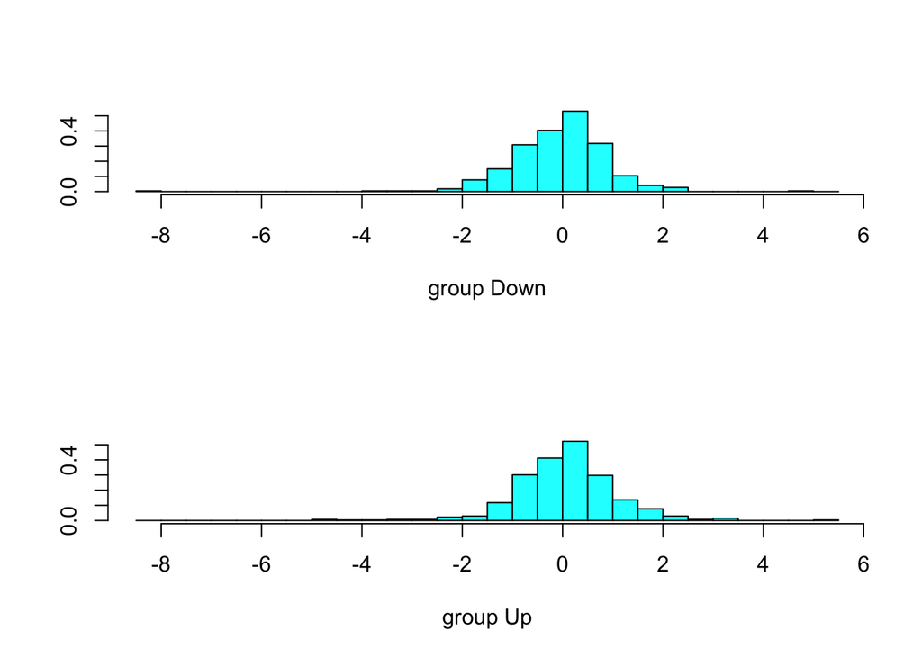

```r
plot(lda.fit.train)
```

```r
lda.probs.test=predict(lda.fit.train,Weekly.test)
lda.class = lda.probs.test$class
table(lda.class,Direction[test])
```

```
##
## lda.class Down Up
##      Down    9  5
##      Up     34 56
```

```r
mean(lda.class==Direction[test])
```

```
## [1] 0.625
```

```r
table(lda.class, glm.pred.test)
```

```
##          glm.pred.test
## lda.class Down Up
##      Down   14  0
##      Up      0 90
```

LDA categorizations perfectly match up with logistic regression.

##### F.

```r
qda.fit.train=qda(Direction ~ Lag2, data=Weekly ,subset= !test)
qda.fit.train
```

```
## Call:
## qda(Direction ~ Lag2, data = Weekly, subset = !test)
##
## Prior probabilities of groups:
##      Down        Up
## 0.4477157 0.5522843
##
## Group means:
##             Lag2
## Down -0.03568254
## Up    0.26036581
```

```r
qda.probs.test=predict(qda.fit.train,Weekly.test)
qda.class = qda.probs.test$class
table(qda.class,Direction[test])
```

```
##
## qda.class Down Up
##      Down    0  0
##      Up     43 61
```

```r
mean(qda.class==Direction[test])
```

```
## [1] 0.5865385
```

##### G.

```r
library(class)
set.seed(1)
train.X = Lag2[!test]
test.X = Lag2[test]
knn.pred=knn(as.matrix(train.X),as.matrix(test.X),as.matrix(Direction[!test]) ,k=1)
table(knn.pred,Direction[test])
```

```
##
## knn.pred Down Up
##     Down   21 30
##     Up     22 31
```

```r
mean(knn.pred==Direction[test])
```

```
## [1] 0.5
```

##### G.

```r
library(class)
set.seed(1)
knn.pred=knn(as.matrix(train.X),as.matrix(test.X),as.matrix(Direction[!test]) ,k=2)
table(knn.pred,Direction[test])
```

```
##
## knn.pred Down Up
##     Down   19 27
##     Up     24 34
```

```r
mean(knn.pred==Direction[test])
```

```
## [1] 0.5096154
```

```r
knn.pred=knn(as.matrix(train.X),as.matrix(test.X),as.matrix(Direction[!test]) ,k=3)
table(knn.pred,Direction[test])
```

```
##
## knn.pred Down Up
##     Down   15 19
##     Up     28 42
```

```r
mean(knn.pred==Direction[test])
```

```
## [1] 0.5480769
```

```r
knn.pred=knn(as.matrix(train.X),as.matrix(test.X),as.matrix(Direction[!test]) ,k=4)
table(knn.pred,Direction[test])
```

```
##
## knn.pred Down Up
##     Down   20 19
##     Up     23 42
```

```r
mean(knn.pred==Direction[test])
```

```
## [1] 0.5961538
```

```r
knn.pred=knn(as.matrix(train.X),as.matrix(test.X),as.matrix(Direction[!test]) ,k=5)
table(knn.pred,Direction[test])
```

```
##
## knn.pred Down Up
##     Down   16 22
##     Up     27 39
```

```r
mean(knn.pred==Direction[test])
```

```
## [1] 0.5288462
```

```r
knn.pred=knn(as.matrix(train.X),as.matrix(test.X),as.matrix(Direction[!test]) ,k=10)
table(knn.pred,Direction[test])
```

```
##
## knn.pred Down Up
##     Down   19 18
##     Up     24 43
```

```r
mean(knn.pred==Direction[test])
```

```
## [1] 0.5961538
```

```r
qda.fit.train=qda(Direction ~ Lag1 + Lag2, data=Weekly ,subset= !test)
qda.fit.train
```

```
## Call:
## qda(Direction ~ Lag1 + Lag2, data = Weekly, subset = !test)
##
## Prior probabilities of groups:
##      Down        Up
## 0.4477157 0.5522843
##
## Group means:
##              Lag1        Lag2
## Down  0.289444444 -0.03568254
## Up   -0.009213235  0.26036581
```

```r
qda.probs.test=predict(qda.fit.train,Weekly.test)
qda.class = qda.probs.test$class
table(qda.class,Direction[test])
```

```
##
## qda.class Down Up
##      Down    7 10
##      Up     36 51
```

```r
mean(qda.class==Direction[test])
```

```
## [1] 0.5576923
```

Adding additional KNN points increases the performance of KNN; however, KNN performance still lags LDA. Adding additional predictors to QDA only seems to make the fit accuracy worse.

### Problem 11

##### A.

```r
mpg01 <- rep(0, dim(Auto)[1])
mpg01[Auto$mpg > median(Auto$mpg)] <- 1
Auto <- cbind(Auto, mpg01)
```

##### B.

```r
summary(Auto)
```

```
##       mpg          cylinders      displacement     horsepower
##  Min.   : 9.00   Min.   :3.000   Min.   : 68.0   Min.   : 46.0
##  1st Qu.:17.00   1st Qu.:4.000   1st Qu.:105.0   1st Qu.: 75.0
##  Median :22.75   Median :4.000   Median :151.0   Median : 93.5
##  Mean   :23.45   Mean   :5.472   Mean   :194.4   Mean   :104.5
##  3rd Qu.:29.00   3rd Qu.:8.000   3rd Qu.:275.8   3rd Qu.:126.0
##  Max.   :46.60   Max.   :8.000   Max.   :455.0   Max.   :230.0
##
##      weight      acceleration        year           origin
##  Min.   :1613   Min.   : 8.00   Min.   :70.00   Min.   :1.000
##  1st Qu.:2225   1st Qu.:13.78   1st Qu.:73.00   1st Qu.:1.000
##  Median :2804   Median :15.50   Median :76.00   Median :1.000
##  Mean   :2978   Mean   :15.54   Mean   :75.98   Mean   :1.577
##  3rd Qu.:3615   3rd Qu.:17.02   3rd Qu.:79.00   3rd Qu.:2.000
##  Max.   :5140   Max.   :24.80   Max.   :82.00   Max.   :3.000
##
##                  name         mpg01
##  amc matador       :  5   Min.   :0.0
##  ford pinto        :  5   1st Qu.:0.0
##  toyota corolla    :  5   Median :0.5
##  amc gremlin       :  4   Mean   :0.5
##  amc hornet        :  4   3rd Qu.:1.0
##  chevrolet chevette:  4   Max.   :1.0
##  (Other)           :365
```

```r
table(Auto$mpg01, Auto$cylinders)
```

```
##
##       3   4   5   6   8
##   0   3  20   1  72 100
##   1   1 179   2  11   3
```

```r
#More cylinders = less likely to have mpg01 = 1

table(Auto$mpg01, Auto$origin)
```

```
##
##       1   2   3
##   0 173  14   9
##   1  72  54  70
```

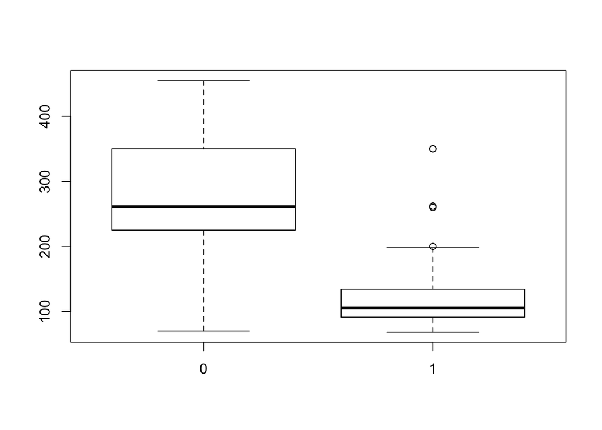

```r
#Japanese and European cars seem more fuel efficient, American cars less so

plot(as.factor(Auto$mpg01), Auto$displacement)
```

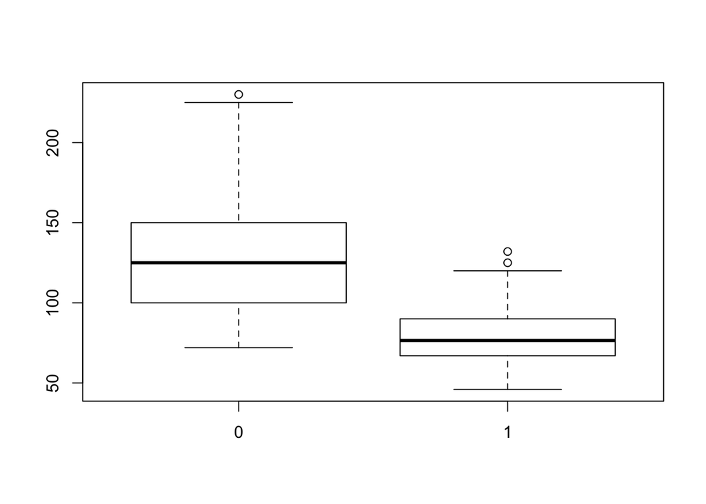

```r
#Lower displacement implies more fuel efficient

plot(as.factor(Auto$mpg01), Auto$horsepower)
```

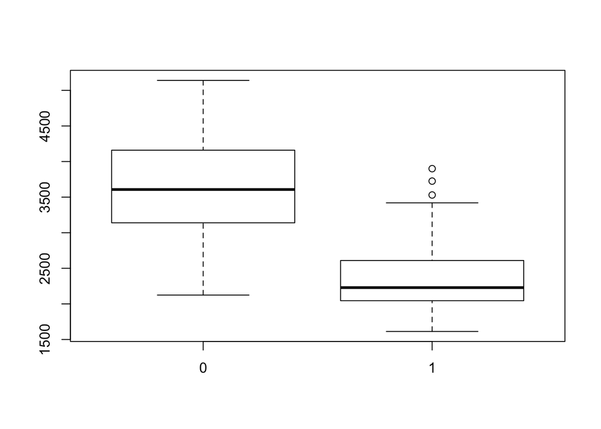

```r
#Lower horsepower implies more fuel efficient

plot(as.factor(Auto$mpg01), Auto$weight)
```

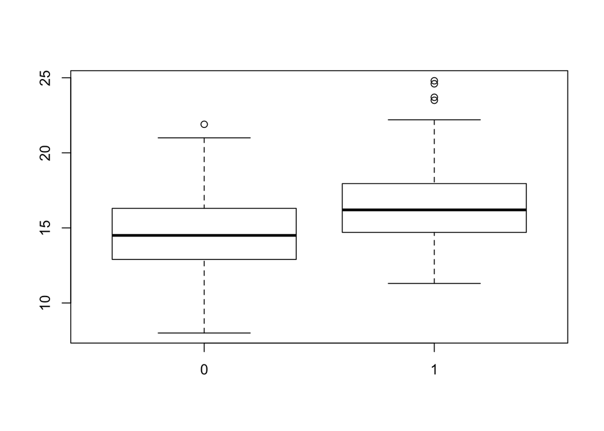

```r
#Lower weight implies more fuel efficient

plot(as.factor(Auto$mpg01), Auto$acceleration)
```

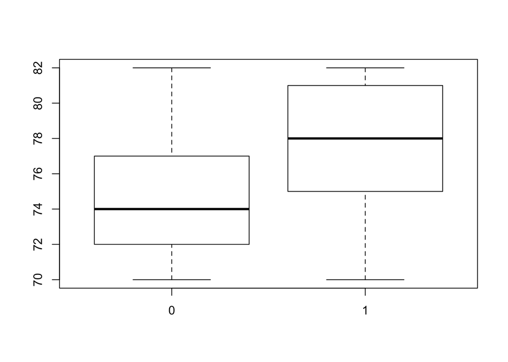

```r
#Slower acceleration implies more fuel efficient

plot(as.factor(Auto$mpg01), Auto$year)
```

```r
#Later model year implies more fuel efficient
```

##### C.

```r
set.seed(1)
data.length <- dim(Auto)[1]
sample.set <- sample(seq(1, data.length), data.length/2, replace = FALSE)
train <- rep(FALSE, data.length)
train[sample.set] <- TRUE
test.set <- Auto[!train,]
#train.set <- Auto[train,]
```

##### D.

```r
auto.lda.fit<-lda(mpg01  ~ weight+year, data=Auto, subset=train)
auto.lda.fit
```

```
## Call:
## lda(mpg01 ~ weight + year, data = Auto, subset = train)
##
## Prior probabilities of groups:
##         0         1
## 0.5255102 0.4744898
##
## Group means:
##     weight     year
## 0 3636.359 74.72816
## 1 2404.151 77.94624
##
## Coefficients of linear discriminants:
##                 LD1
## weight -0.001546518
## year    0.118242263
```

```r
auto.lda.predict<-predict(auto.lda.fit, newdata=test.set)
table(test.set$mpg01, auto.lda.predict$class)
```

```
##
##       0   1
##   0  78  15
##   1   1 102
```

```r
mean(test.set$mpg01==auto.lda.predict$class)
```

```
## [1] 0.9183673
```

##### E.

```r
auto.qda.fit=qda(mpg01  ~ weight+year, data=Auto, subset=train)
auto.qda.fit
```

```
## Call:
## qda(mpg01 ~ weight + year, data = Auto, subset = train)
##
## Prior probabilities of groups:
##         0         1
## 0.5255102 0.4744898
##
## Group means:
##     weight     year
## 0 3636.359 74.72816
## 1 2404.151 77.94624
```

```r
auto.qda.predict<-predict(auto.qda.fit, newdata=test.set)
table(test.set$mpg01, auto.qda.predict$class)
```

```
##
##       0   1
##   0  77  16
##   1   3 100
```

```r
mean(test.set$mpg01==auto.qda.predict$class)
```

```
## [1] 0.9030612
```

##### F.

```r
auto.glm.fit=glm(mpg01  ~ weight+year, data=Auto, family=binomial, subset=train)
summary(auto.glm.fit)
```

```
##
## Call:
## glm(formula = mpg01 ~ weight + year, family = binomial, data = Auto,
##     subset = train)
##
## Deviance Residuals:
##      Min        1Q    Median        3Q       Max
## -2.34069  -0.27079  -0.00577   0.28838   2.69835
##
## Coefficients:
##               Estimate Std. Error z value Pr(>|z|)
## (Intercept) -2.034e+01  6.543e+00  -3.108  0.00188 **
## weight      -4.659e-03  7.175e-04  -6.493 8.40e-11 ***
## year         4.417e-01  9.853e-02   4.482 7.38e-06 ***
## ---
## Signif. codes:  0 '***' 0.001 '**' 0.01 '*' 0.05 '.' 0.1 ' ' 1
##
## (Dispersion parameter for binomial family taken to be 1)
##
##     Null deviance: 271.203  on 195  degrees of freedom
## Residual deviance:  97.672  on 193  degrees of freedom
## AIC: 103.67
##
## Number of Fisher Scoring iterations: 7
```

```r
auto.glm.predict <- predict(auto.glm.fit, newdata=test.set, type = "response")
auto.glm.pred.test=rep(0,data.length/2)
auto.glm.pred.test[auto.glm.predict >.5]=1
mean(test.set$mpg01 == auto.glm.pred.test)
```

```
## [1] 0.9132653
```

```r
table(test.set$mpg01,auto.glm.pred.test)
```

```
##    auto.glm.pred.test
##      0  1
##   0 82 11
##   1  6 97
```

##### G.

```r
set.seed(1)
standardized.X=scale(subset(Auto, select=c(weight, year)))
train.X=standardized.X[train,]
test.X=standardized.X[!train,]
train.Y=Auto$mpg01[train]
test.Y=Auto$mpg01[!train]
test_loops = c(1, 2, 3, 4, 5, 7, 10, 12, 15, 20, 25, 30, 40, 50)
for (n in test_loops){
  knn.pred=knn(train.X,test.X,train.Y,k=n)
  print(paste(n, mean(test.Y==knn.pred)))
}
```

```
## [1] "1 0.908163265306122"
## [1] "2 0.933673469387755"
## [1] "3 0.918367346938776"
## [1] "4 0.903061224489796"
## [1] "5 0.913265306122449"
## [1] "7 0.928571428571429"
## [1] "10 0.928571428571429"
## [1] "12 0.923469387755102"
## [1] "15 0.923469387755102"
## [1] "20 0.918367346938776"
## [1] "25 0.913265306122449"
## [1] "30 0.913265306122449"
## [1] "40 0.903061224489796"
## [1] "50 0.928571428571429"
```

### Problem 12

##### A.

```r
Power=function(){
  print(2^3)
}

Power()
```

```
## [1] 8
```

##### B.

```r
Power2=function(x,a){
  print(x^a)
}

Power2(3,8)
```

```
## [1] 6561
```

##### C.

```r
Power2(10,3)
```

```
## [1] 1000
```

```r
Power2(8,17)
```

```
## [1] 2.2518e+15
```

```r
Power2(131,3)
```

```
## [1] 2248091
```

##### D.

```r
Power3=function(x,a){
  return(x^a)
}
```

##### E.

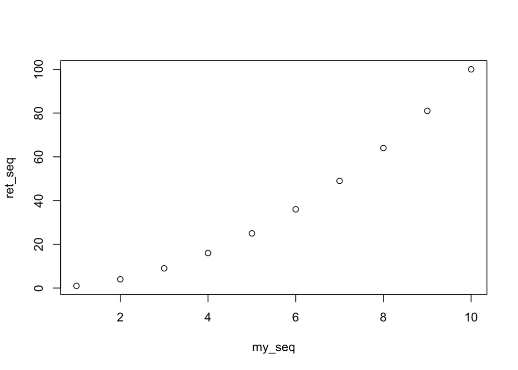

```r
my_seq = seq(1, 10)
ret_seq = rep(0, length(my_seq))
loop_counter = 1
for(element in my_seq){
  ret_seq[loop_counter] = Power3(element, 2)
  loop_counter=loop_counter+1
}
plot(my_seq, ret_seq)
```

##### F.

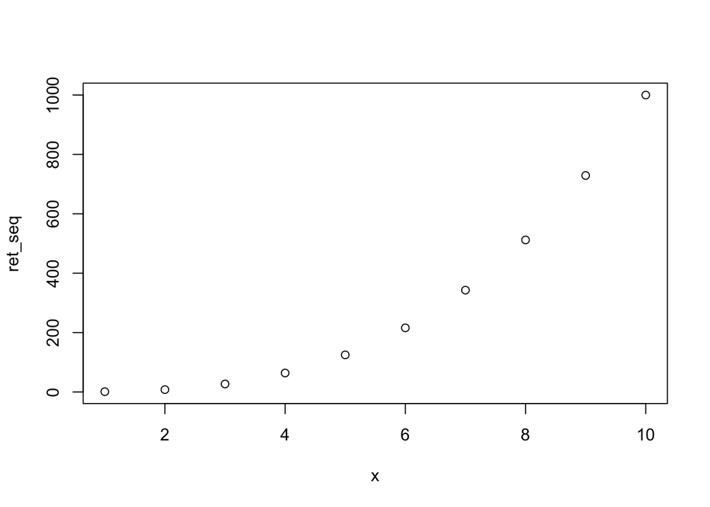

```r
PowerPlot = function(x, a){
  ret_seq = rep(0, length(x))
  loop_counter = 1
  for(element in x){
    ret_seq[loop_counter] = Power3(element, a)
    loop_counter=loop_counter+1
  }
  plot(x, ret_seq)
}

PowerPlot(1:10, 3)
```